# mobile_app

## Обзор данных

Выгрузим данные о поведении пользователей из csv-файла в датафрейм и сохраним его в переменной `logs`.

```python
# загружаем библиотеки
import pandas as pd
import datetime as dt
from matplotlib import pyplot as plt
import seaborn as sns
from scipy import stats as st
import numpy as np
import math as mth
```

```python
# загружаем данные
try:
    logs = pd.read_csv('/datasets/logs_exp.csv', sep='\t')
except FileNotFoundError:
    display('Такого файла не существует!')
```

Выведем 10 строчек датафрейма `logs` на экран.

```python
logs.sample(10)
```

|  | EventName | DeviceIDHash | EventTimestamp | ExpId |
| --- | --- | --- | --- | --- |
| 90811 | OffersScreenAppear | 5006225713885460557 | 1564835129 | 247 |
| 60890 | PaymentScreenSuccessful | 3003444229104601988 | 1564756433 | 248 |
| 94916 | MainScreenAppear | 7300435892325726869 | 1564841923 | 248 |
| 183939 | MainScreenAppear | 8751941392761811595 | 1565076263 | 247 |
| 172330 | CartScreenAppear | 8896240631357211388 | 1565029354 | 248 |
| 185248 | OffersScreenAppear | 2204195013513295394 | 1565079022 | 248 |
| 127936 | MainScreenAppear | 1741785633060377552 | 1564928835 | 247 |
| 206669 | CartScreenAppear | 5350532170097222952 | 1565113607 | 248 |
| 210197 | MainScreenAppear | 4563180381186480517 | 1565119566 | 247 |
| 168600 | MainScreenAppear | 8441020992042856535 | 1565023763 | 247 |

**Таблица содержит следующую информацию:**

- `EventName` - название события;
- `DeviceIDHash` - уникальный идентификатор пользователя;
- `EventTimestamp` - время события;
- `ExpId` - номер эксперимента.

Группа 246 и 247 - контрольные группы, а группа 248 - экспериментальная. Каждая запись в логе - это действие пользователя, или событие.

Выведем основную информацию о датафрейме.

```python
logs.info()
```

```
<class 'pandas.core.frame.DataFrame'>
RangeIndex: 244126 entries, 0 to 244125
Data columns (total 4 columns):
 #   Column          Non-Null Count   Dtype
---  ------          --------------   -----
 0   EventName       244126 non-null  object
 1   DeviceIDHash    244126 non-null  int64
 2   EventTimestamp  244126 non-null  int64
 3   ExpId           244126 non-null  int64
dtypes: int64(3), object(1)
memory usage: 7.5+ MB
```

Таблица с исходными данными содержит 4 столбца и 244126 строк.

## Предобработка данных

### Замена названия столбцов

Заменим названия столбцов на удобные и понятные для нас:

- `EventName` на `event_name` - название события;
- `DeviceIDHash` на `user_id` - уникальный идентификатор пользователя;
- `EventTimestamp` на `event_time` - время события;
- `ExpId` на `exp_id` - номер эксперимента.

```python
logs = logs.rename(columns={'EventName':'event_name', 'DeviceIDHash':'user_id', 'EventTimestamp':'event_time', \
                            'ExpId':'exp_id'})
```

```python
# check
logs.columns
```

```
Index(['event_name', 'user_id', 'event_time', 'exp_id'], dtype='object')
```

### Удаление пропусков

Проверим наши данные на наличие пропусков.

```python
logs.isna().sum()
```

```
event_name    0
user_id       0
event_time    0
exp_id        0
dtype: int64
```

Пропусков в данных нет.

Проверим данные на количество дубликатов.

```python
logs.duplicated().sum()
```

```
413
```

В данных есть явные дубликаты, удалим их с помощью метода `drop_duplicates()`.

```python
logs = logs.drop_duplicates().reset_index(drop=True)
logs.tail()
```

|  | event_name | user_id | event_time | exp_id |
| --- | --- | --- | --- | --- |
| 243708 | MainScreenAppear | 4599628364049201812 | 1565212345 | 247 |
| 243709 | MainScreenAppear | 5849806612437486590 | 1565212439 | 246 |
| 243710 | MainScreenAppear | 5746969938801999050 | 1565212483 | 246 |
| 243711 | MainScreenAppear | 5746969938801999050 | 1565212498 | 246 |
| 243712 | OffersScreenAppear | 5746969938801999050 | 1565212517 | 246 |

```python
# check
logs.duplicated().sum()
```

```
0
```

### Изменение типов данных

Изучим типы данных в нашем датафрейме.

```python
logs.dtypes
```

```
event_name    object
user_id        int64
event_time     int64
exp_id         int64
dtype: object
```

Столбец `event_time` содержит тип `int`, изменим его на `datetime` с помощью `Timestamp`.

```python
logs['event_time'] = logs['event_time'].map(lambda x: pd.Timestamp(x, unit='s'))
```

```python
# check
logs['event_time'].head()
```

```
0   2019-07-25 04:43:36
1   2019-07-25 11:11:42
2   2019-07-25 11:28:47
3   2019-07-25 11:28:47
4   2019-07-25 11:48:42
Name: event_time, dtype: datetime64[ns]
```

```python
# check
logs.dtypes
```

```
event_name            object
user_id                int64
event_time    datetime64[ns]
exp_id                 int64
dtype: object
```

Изменили тип данных в столбце `event_time` на `datetime`.

### Добавление новых столбцов

Добавим столбец `event_date_time`, который будет содержать дату и время, и столбец `event_date`, который будет содержать дату.

```python
logs['event_date_time'] = pd.to_datetime(logs['event_time'])
logs['event_date_time'].head()
```

```
0   2019-07-25 04:43:36
1   2019-07-25 11:11:42
2   2019-07-25 11:28:47
3   2019-07-25 11:28:47
4   2019-07-25 11:48:42
Name: event_date_time, dtype: datetime64[ns]
```

```python
logs['event_date'] = pd.to_datetime(logs['event_time']).dt.date
logs['event_date'] = pd.to_datetime(logs['event_date'])
logs['event_date'].head()
```

```
0   2019-07-25
1   2019-07-25
2   2019-07-25
3   2019-07-25
4   2019-07-25
Name: event_date, dtype: datetime64[ns]
```

```python
# check
logs.info()
```

```
<class 'pandas.core.frame.DataFrame'>
RangeIndex: 243713 entries, 0 to 243712
Data columns (total 6 columns):
 #   Column           Non-Null Count   Dtype
---  ------           --------------   -----
 0   event_name       243713 non-null  object
 1   user_id          243713 non-null  int64
 2   event_time       243713 non-null  datetime64[ns]
 3   exp_id           243713 non-null  int64
 4   event_date_time  243713 non-null  datetime64[ns]
 5   event_date       243713 non-null  datetime64[ns]
dtypes: datetime64[ns](3), int64(2), object(1)
memory usage: 11.2+ MB
```

Добавили два новых столбца `event_date_time` и `event_date`.

```python
aab_users = logs.groupby('user_id').agg({'exp_id': ['nunique', 'unique']})
aab_users.columns = ['groups', 'group_name']
aab_users = aab_users.query('groups > 1')
print('Количество пользователей в группе 246:', logs.query('exp_id == 246')['user_id'].nunique())
print('Количество пользователей в группе 247:', logs.query('exp_id == 247')['user_id'].nunique())
print('Количество пользователей в группе 248:', logs.query('exp_id == 248')['user_id'].nunique())
print('Количество пользователей, попавших в две и более группы:', len(aab_users))
```

```
Количество пользователей в группе 246: 2489
Количество пользователей в группе 247: 2520
Количество пользователей в группе 248: 2542
Количество пользователей, попавших в две и более группы: 0
```

## Исследование данных

### Количество событий в логе

Узнаем какие действия совершают пользователи нашего приложения.

```python
logs.event_name.unique()
```

```
array(['MainScreenAppear', 'PaymentScreenSuccessful', 'CartScreenAppear',
       'OffersScreenAppear', 'Tutorial'], dtype=object)
```

Всего в логе пять событий:

- `MainScreenAppear` - это событие возникает, когда пользователь запускает главный экран или главную страницу нашего приложения. Обычно это используется для отслеживания того, сколько раз пользователь запускает приложение и как долго он находится на главном экране.
- `PaymentScreenSuccessful` - это событие возникает, когда пользователь успешно завершает платежный процесс на экране оплаты в приложении. Обычно это используется для отслеживания количества успешных транзакций и общей суммы дохода приложения от платежей.
- `CartScreenAppear` - это событие возникает, когда пользователь открывает экран корзины в приложении. Обычно это используется для отслеживания того, сколько раз пользователь просматривает свою корзину и сколько времени он проводит на этом экране.
- `OffersScreenAppear` - это событие возникает, когда пользователь открывает экран с предложениями в приложении. Обычно это используется для отслеживания того, какие предложения наиболее популярны среди пользователей и сколько времени они проводят на этом экране.
- `Tutorial` - это обучающий материал, который помогает пользователю разобраться в нашем приложении.

Узнаем количество всех событий в логе.

```python
events = logs.event_name.count()
events
```

```
243713
```

Всего в логе 243713 событий. Посчитаем количество событий для каждого наименования.

```python
event_name = (logs
              .groupby(['event_name'])
              .agg(count = ('event_name', 'count'))
              .sort_values(by = 'count', ascending = False)
             )
event_name
```

| event_name | count |
| --- | --- |
| MainScreenAppear | 119101 |
| OffersScreenAppear | 46808 |
| CartScreenAppear | 42668 |
| PaymentScreenSuccessful | 34118 |
| Tutorial | 1018 |

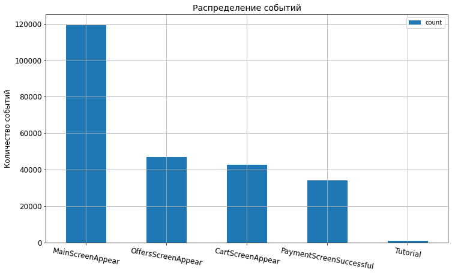

```python
# визуализируем данные таблицы 'event_name'
event_name.reset_index()
event_name.plot(kind='bar',
                figsize = (12, 7),
                rot = -10, grid = True,
                legend = True,
                fontsize = 12);

plt.ylabel('Количество событий', fontsize = 12)
plt.xlabel('', fontsize = 12)
plt.title('Распределение событий', fontsize = 14);

plt.show()
```

На графике мы видим, что чаще всего пользователи запускает главную страницу нашего приложения, реже всего используют обучающий материал.

### Количество пользователей в логе

Узнаем какое количество уникальных пользователей в нашем логе.

```python
users = logs['user_id'].nunique()
users
```

```
7551
```

В нашем датафрейме 7551 уникальных пользователей.

### Среднее количество событий на одного пользователя

По полученным данным выше, найдем среднее количество событий на одного пользователя.

```python
event_per_user = events / users
# округлим полученное значение до целого числа
round(event_per_user)
```

```
32
```

На каждого пользователя приходится в среднем 32 события.

```python
# соберем данные о количестве событий на каждого пользователя
events_user = logs.pivot_table(index='user_id', values='event_name', aggfunc='count')
events_user.head()
```

| user_id | event_name |
| --- | --- |
| 6888746892508752 | 1 |
| 6909561520679493 | 5 |
| 6922444491712477 | 47 |
| 7435777799948366 | 6 |
| 7702139951469979 | 137 |

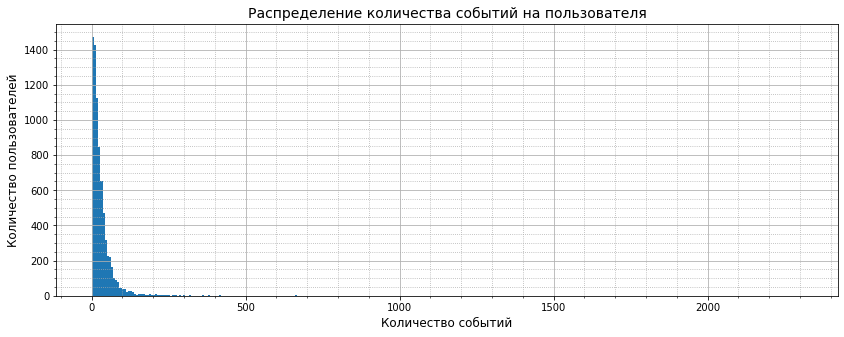

```python
# визуализируем данные таблицы 'events_user'
events_user.reset_index()
events_user.hist(bins=14*24, figsize=(14, 5))

plt.minorticks_on()
plt.grid(which='minor', color='#aaa', ls=':')

plt.ylabel('Количество пользователей', fontsize = 12)
plt.xlabel('Количество событий', fontsize = 12)
plt.title('Распределение количества событий на пользователя', fontsize = 14);

plt.show()
```

### Период времени всех событий. Количество данных за весь период. Период времени, данными которыми мы располагаем на самом деле

Узнаем, данными за какой период мы располагаем. Для этого найдем минимальную и максимальную даты нашего датафрейма.

```python
logs['event_date'].min(), logs['event_date'].max()
```

```
(Timestamp('2019-07-25 00:00:00'), Timestamp('2019-08-07 00:00:00'))
```

Все события в нашем логе происходили в период с 25 июля по 7 августа 2019 года. Посмотрим на распределение количества событий, совершенных пользователями за весь период. Для этого создадим сводную таблицу `events_per_time` и сгруппируем данные по столбу `event_date`.

```python
events_per_time = logs.groupby(['event_date']).agg(count = ('event_name', 'count'))
events_per_time
```

| event_date | count |
| --- | --- |
| 2019-07-25 | 9 |
| 2019-07-26 | 31 |
| 2019-07-27 | 55 |
| 2019-07-28 | 105 |
| 2019-07-29 | 184 |
| 2019-07-30 | 412 |
| 2019-07-31 | 2030 |
| 2019-08-01 | 36141 |
| 2019-08-02 | 35554 |
| 2019-08-03 | 33282 |
| 2019-08-04 | 32968 |
| 2019-08-05 | 36058 |
| 2019-08-06 | 35788 |
| 2019-08-07 | 31096 |

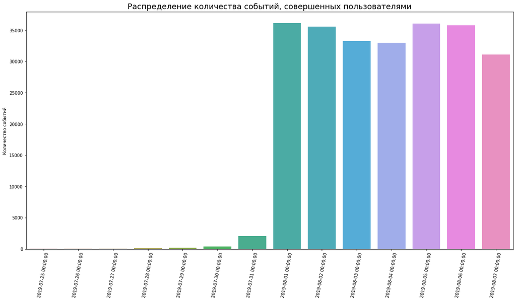

```python
# визуализируем данные таблицы 'events_per_time'
fig = plt.figure()

sns.barplot(x = events_per_time.index, y = events_per_time['count'])

plt.title('Распределение количества событий, совершенных пользователями', fontsize = 18, color = 'k')
plt.xlabel('')
plt.xticks(rotation=80);
plt.ylabel('Количество событий');

fig.set_figwidth(20)
fig.set_figheight(10)

plt.show()
```

На графике мы видим, что до 31 июля включительно, событий было очень мало, по сравнению с их количеством 1 августа. С 1 по 7 августа данные более полные, поэтому отбросим данные в период с 25 по 31 июля 2019 года. Более полные данные сохраним в переменной `logs_actual`.

```python
logs_actual = logs[(logs['event_date']) > '2019-07-31']

# проверим период времени 'logs_actual'
logs_actual.event_date.describe(datetime_is_numeric=True)
```

```
count                           240887
mean     2019-08-03 22:48:55.002718976
min                2019-08-01 00:00:00
25%                2019-08-02 00:00:00
50%                2019-08-04 00:00:00
75%                2019-08-06 00:00:00
max                2019-08-07 00:00:00
Name: event_date, dtype: object
```

Таблица `logs_actual` содержит более полные данные в период с 1 по 7 августа 2019 года.

### Количество событий и пользователей, которых мы потеряли отбросив старые данные

Узнаем какое количество событий мы потеряли, отбросив старые данные.

```python
# количество событий с в период с 1 по 7 августа 2019 года
actual_events = logs_actual.event_name.count()

# переменная 'events' содержит количество событий с в период с 25 июля по 7 августа 2019 года
# количество событий, которые мы потеряли в абсолютной величине
abs_lost_events = events - actual_events
# количество событий, которые мы потеряли в относительной величине
rel_lost_events = abs_lost_events * 100 / events

print('Количество событий, которые мы потеряли в абсолютной величине:', abs_lost_events)
print('Количество событий, которые мы потеряли в относительной величине:', round(rel_lost_events, 2), '%')
```

```
Количество событий, которые мы потеряли в абсолютной величине: 2826
Количество событий, которые мы потеряли в относительной величине: 1.16 %
```

Мы потеряли 2826 или 1,16% действий в нашем приложении, отбросив старые данные.

Узнаем, какое количество пользователей мы потеряли, отбросив старые данные.

```python
# количество уникальных пользователей в период с 1 по 7 августа 2019 года
actual_users = logs_actual['user_id'].nunique()

# переменная 'users' содержит количество уникальных пользователей в период с 25 июля по 7 августа 2019 года
# количество пользователей, которых мы потеряли в абсолютной величине
abs_lost_users = users - actual_users
# количество пользователей, которых мы потеряли в абсолютной величине
rel_lost_users = abs_lost_users * 100 / users

print('Количество пользователей, которых мы потеряли в абсолютной величине:', abs_lost_users)
print('Количество пользователей, которых мы потеряли в относительной величине:', round(rel_lost_users, 2), '%')
```

```
Количество пользователей, которых мы потеряли в абсолютной величине: 17
Количество пользователей, которых мы потеряли в относительной величине: 0.23 %
```

Отбросив старые данные мы потеряли 2826 действий, совершенных 17 уникальными пользователями.

### Количество пользователей из всех трёх экспериментальных групп

Проверим, что у нас есть пользователи из всех трёх экспериментальных групп.

```python
actual_exp_id = (logs_actual
                 .groupby(['exp_id'])
                 .agg(count = ('user_id', 'nunique'))
                 .sort_values(by = 'exp_id')
                )

actual_exp_id
```

| exp_id | count |
| --- | --- |
| 246 | 2484 |
| 247 | 2513 |
| 248 | 2537 |

У нас есть пользователи во всех трех экспериментальных группах, стоит отметить, что их количество практически одинаковое.

## Исследование воронки событий

### Количество событий в логе с полными данными

Узнаем количество событий для каждого наименования в датафрейме `logs_actual`.

```python
actual_event_name = (logs_actual
                     .groupby(['event_name'])
                     .agg(count = ('event_name', 'count'))
                     .sort_values(by = 'count', ascending = False)
                    )
actual_event_name
```

| event_name | count |
| --- | --- |
| MainScreenAppear | 117328 |
| OffersScreenAppear | 46333 |
| CartScreenAppear | 42303 |
| PaymentScreenSuccessful | 33918 |
| Tutorial | 1005 |

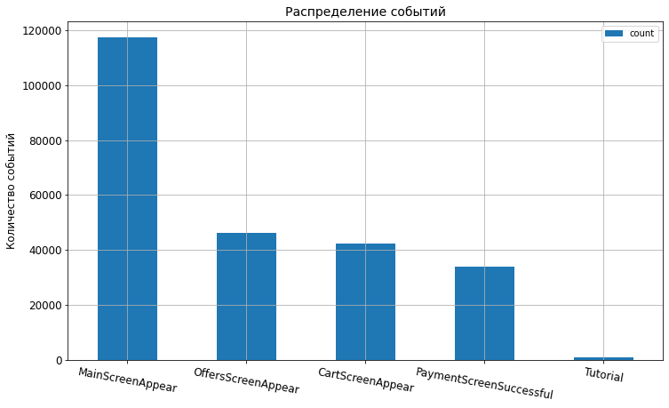

```python
# визуализируем данные таблицы 'actual_event_name'
actual_event_name.reset_index()
actual_event_name.plot(kind='bar',
                       figsize = (12, 7),
                       rot = -10, grid = True,
                       legend = True,
                       fontsize = 12);

plt.ylabel('Количество событий', fontsize = 12)
plt.xlabel('', fontsize = 12)
plt.title('Распределение событий', fontsize = 14);

plt.show()
```

Самое большое количество действий, которое совершают пользователи - это `MainScreenAppear` - запускают главную страницу нашего приложения - 117328 раз пользователи совершили это действие. Реже всего происходит событие `Tutorial` - 1005 раз, малое количество людей обращается к обучающим материалам, значит наше приложение достаточно интуитивное и понятное пользователю. События `OffersScreenAppear`, `CartScreenAppear` и `PaymentScreenSuccessful` - находятся примерно около одного уровня.

### Количество и доля пользователей, которые совершали каждое из событий

Узнаем какое количество пользователей совершали каждое действие в нашем приложении, и также рассчитаем их долю. Мы помним, что количество всех пользователей в период с 1 по 7 августа хранит переменная `actual_users`.

```python
event_name_users = (logs_actual
                    .groupby(['event_name'])
                    .agg(numbers_users = ('user_id', 'nunique'))
                    .sort_values(by = 'numbers_users', ascending = False)
                    )
# добавим столбец 'share_users' - доля пользователей, которые совершили то или иное действие
event_name_users['share_users'] = event_name_users['numbers_users'] / actual_users

# округлим значения столбца 'share_users' до двух знаков после запятой
event_name_users['share_users'] = event_name_users['share_users'].round(2)

event_name_users
```

| event_name | numbers_users | share_users |
| --- | --- | --- |
| MainScreenAppear | 7419 | 0.98 |
| OffersScreenAppear | 4593 | 0.61 |
| CartScreenAppear | 3734 | 0.50 |
| PaymentScreenSuccessful | 3539 | 0.47 |
| Tutorial | 840 | 0.11 |

Самая большая доля пользователей запускает экран приложения - 7419 человек. Самая маленькая доля - 840 человек - учится пользоваться нашим приложением. Около половины пользователей открывает экран с предложениями, просматривает свою корзину и успешно оплачивает заказ.

### Порядок, в котором происходят события

Предположим порядок в котором происходят события:

1) `MainScreenAppear` - пользователь запускает главный экран или главную страницу приложения;

2) `OffersScreenAppear` - пользователь открывает экран с предложениями приложения;

3) `CartScreenAppea` - пользователь открывает экран корзины;

4) `PaymentScreenSuccessful` - пользователь успешно завершает платежный процесс.

Действие `Tutorial` - изучение обучающего материала не встраивается в эту цепочку, потому что к этому действию пользователь может обратиться в любой момент или не совершать это действие вовсе. Около 90% наших пользователей не совершали этого события. Исключим событие `Tutorial` из наших данных.

```python
logs_actual = logs_actual[(logs_actual['event_name']) != "Tutorial"]
```

```python
# check
logs_actual.event_name.value_counts().to_frame()
```

|  | event_name |
| --- | --- |
| MainScreenAppear | 117328 |
| OffersScreenAppear | 46333 |
| CartScreenAppear | 42303 |
| PaymentScreenSuccessful | 33918 |

```python
# проверим количество уникальных пользователей после удаления события `Tutorial`
actual_users = logs_actual.user_id.nunique()
actual_users
```

```
7530
```

После удаления из данных строк с событием `Tutorial` мы потеряли 4 пользователей.

### Доля пользователей, которая переходит на следующий шаг.

Узнаем какая доля пользователей переходит к следующему шагу нашей воронки событий.

```python
event_name_users = (logs_actual
                    .groupby(['event_name'])
                    .agg(numbers_users = ('user_id', 'nunique'))
                    .sort_values(by = 'numbers_users', ascending = False)
                    )
# добавим столбец 'share_users' - доля пользователей, которые совершили то или иное действие
event_name_users['share_users'] = event_name_users['numbers_users'] / actual_users

# округлим значения столбца 'share_users' до двух знаков после запятой
event_name_users['share_users'] = event_name_users['share_users'].round(2)

# добавим столбец 'share_from_prev_step' - доля пользователей, котороая проходит на следующий шаг воронки
event_name_users['share_from_prev_step'] = \
event_name_users['numbers_users'] / event_name_users['numbers_users'].shift()

# округлим значения столбца 'share_users_step' до двух знаков после запятой
event_name_users['share_from_prev_step'] = event_name_users['share_from_prev_step'].round(2)

event_name_users
```

| event_name | numbers_users | share_users | share_from_prev_step |
| --- | --- | --- | --- |
| MainScreenAppear | 7419 | 0.99 | NaN |
| OffersScreenAppear | 4593 | 0.61 | 0.62 |
| CartScreenAppear | 3734 | 0.50 | 0.81 |
| PaymentScreenSuccessful | 3539 | 0.47 | 0.95 |

Самая маленькая доля пользователей переходит от события `MainScreenAppear` к событию `OffersScreenAppear` - 62% пользователей. Самая большая доля пользователей переходит с `CartScreenAppear` к `PaymentScreenSuccessful` - 95%.

### Шаг, на котором теряется больше всего пользователей

Посчитаем, какую долю пользователей мы теряем от перехода к следующему шагу нашей воронки событий.

```python
# добавим столбец 'share_lost_users' - доля пользователей, которую мы теряем при переходе на следующий шаг воронки
event_name_users['share_lost_users'] = 1 - event_name_users['share_from_prev_step']

event_name_users
```

| event_name | numbers_users | share_users | share_from_prev_step | share_lost_users |
| --- | --- | --- | --- | --- |
| MainScreenAppear | 7419 | 0.99 | NaN | NaN |
| OffersScreenAppear | 4593 | 0.61 | 0.62 | 0.38 |
| CartScreenAppear | 3734 | 0.50 | 0.81 | 0.19 |
| PaymentScreenSuccessful | 3539 | 0.47 | 0.95 | 0.05 |

При переходе с главного экрана приложения `MainScreenAppear` к предложениям приложения `OffersScreenAppear` терятся самая большая доля пользователей - 38%.

### Доля пользователей, которая доходит от первого события до оплаты

Узнаем, какая доля пользователей доходит от первого события до оплаты.

```python
# обратимся к последнему и первому значению столбца 'numbers_users' таблицы `share_main_to_payment`
share_main_to_payment = \
event_name_users['numbers_users'].iloc[-1] / event_name_users['numbers_users'].iloc[0]

round(share_main_to_payment, 2)
```

```
0.48
```

От первого события воронки до оплаты доходит 48% пользователей.

## Исследование результатов эксперимента

### Количество пользователей в каждой экспериментальной группе

```python
users_exp_id = (logs_actual
                 .groupby(['exp_id'])
                 .agg(count = ('user_id', 'nunique'))
                 .sort_values(by = 'exp_id')
                )

users_exp_id
```

| exp_id | count |
| --- | --- |
| 246 | 2483 |
| 247 | 2512 |
| 248 | 2535 |

```python
print('Сумма пользователей из трех групп равна:', users_exp_id['count'].sum())
print('Общее количество пользователей равно:', actual_users)
```

```
Сумма пользователей из трех групп равна: 7530
Общее количество пользователей равно: 7530
```

В каждой экспериментальной группе практически одинаковое количество пользователей. Сумма пользователей из трёх групп равна общему количеству пользователей, таким образом попавший в одну из групп посетитель остаётся в этой группе до конца теста.

### Проведение A/A-теста

Для проведения A/A-теста построим воронку событий для контрольной группы 246 и 247.

```python
# воронка событий для группы 246
exp_246 = (logs_actual
          .query('exp_id == 246')
          .groupby(['event_name'])
          .agg(numbers_users = ('user_id', 'nunique'))
          .sort_values(by = 'numbers_users', ascending = False)
         )

users_246 = users_exp_id['count'].iloc[0]

# добавим столбец 'share_users' - доля пользователей, которые совершили то или иное действие
exp_246['share_users'] = exp_246['numbers_users'] / users_246

# добавим столбец 'share_from_prev_step' - доля пользователей, котороая проходит на следующий шаг воронки
exp_246['share_from_prev_step'] = \
exp_246['numbers_users'] / exp_246['numbers_users'].shift()

# добавим столбец с общим количеством пользователей 'total_users'
exp_246['total_users'] = users_246

cm = sns.light_palette("mediumseagreen", as_cmap=True)

exp_246[['numbers_users', 'share_users', 'share_from_prev_step']].style.background_gradient(cmap=cm)
```

| event_name | numbers_users | share_users | share_from_prev_step |
| --- | --- | --- | --- |
| MainScreenAppear | 2450 | 0.986710 | nan |
| OffersScreenAppear | 1542 | 0.621023 | 0.629388 |
| CartScreenAppear | 1266 | 0.509867 | 0.821012 |
| PaymentScreenSuccessful | 1200 | 0.483286 | 0.947867 |

```python
# воронка событий для группы 247
exp_247 = (logs_actual
          .query('exp_id == 247')
          .groupby(['event_name'])
          .agg(numbers_users = ('user_id', 'nunique'))
          .sort_values(by = 'numbers_users', ascending = False)
         )

users_247 = users_exp_id['count'].iloc[1]

# добавим столбец 'share_users' - доля пользователей, которые совершили то или иное действие
exp_247['share_users'] = exp_247['numbers_users'] / users_247

# добавим столбец 'share_from_prev_step' - доля пользователей, котороая проходит на следующий шаг воронки
exp_247['share_from_prev_step'] = \
exp_247['numbers_users'] / exp_247['numbers_users'].shift()

# добавим столбец с общим количеством пользователей 'total_users'
exp_247['total_users'] = users_247

cm = sns.light_palette("skyblue", as_cmap=True)

exp_247[['numbers_users', 'share_users', 'share_from_prev_step']].style.background_gradient(cmap=cm)
```

| event_name | numbers_users | share_users | share_from_prev_step |
| --- | --- | --- | --- |
| MainScreenAppear | 2476 | 0.985669 | nan |
| OffersScreenAppear | 1520 | 0.605096 | 0.613893 |
| CartScreenAppear | 1238 | 0.492834 | 0.814474 |
| PaymentScreenSuccessful | 1158 | 0.460987 | 0.935380 |

Узнаем, какая доля пользователей доходит от первого события до оплаты в контрольных группах 246 и 247.

```python
share_main_to_payment_246 = \
exp_246['numbers_users'].iloc[-1] / exp_246['numbers_users'].iloc[0]

share_main_to_payment_247 = \
exp_247['numbers_users'].iloc[-1] / exp_247['numbers_users'].iloc[0]

print('Доля пользователей, которая доходит от первого события до оплаты в контрольной группе 246 -', \
      round(share_main_to_payment_246, 2))
print('Доля пользователей, которая доходит от первого события до оплаты в контрольной группе 247 -', \
      round(share_main_to_payment_247, 2))
```

```
Доля пользователей, которая доходит от первого события до оплаты в контрольной группе 246 - 0.49
Доля пользователей, которая доходит от первого события до оплаты в контрольной группе 247 - 0.47
```

Разница между пропорциями, наблюдаемыми на выборках, будет нашей статистикой. Проверим гипотезу о равенстве долей между контрольной группой 246 и 247.

Сформулируем нулевую и альтернативную гипотезу, а также зададим пороговое значение `alpha`.

```
H_0: Доля пользователей, которая доходит от первого события до оплаты в группе 246 = доля пользователей, которая доходит от первого события до оплаты в группе 247
H_a: Доля пользователей, которая доходит от первого события до оплаты в группе 246 ≠ доля пользователей, которая доходит от первого события до оплаты в группе 247
alpha = 0.05
```

```python
# критический уровень статистической значимости
alpha = .05

successes = np.array([exp_246['numbers_users'].iloc[-1], exp_247['numbers_users'].iloc[-1]])
trials = np.array([exp_246['numbers_users'].iloc[0], exp_247['numbers_users'].iloc[0]])

# пропорция успехов в первой группе:
p1 = successes[0]/trials[0]

# пропорция успехов во второй группе:
p2 = successes[1]/trials[1]

# пропорция успехов в комбинированном датасете:
p_combined = (successes[0] + successes[1]) / (trials[0] + trials[1])

# разница пропорций в датасетах
difference = p1 - p2

# считаем статистику в ст.отклонениях стандартного нормального распределения
z_value = difference / mth.sqrt(p_combined * (1 - p_combined) * (1/trials[0] + 1/trials[1]))

# задаем стандартное нормальное распределение (среднее 0, ст.отклонение 1)
distr = st.norm(0, 1)

p_value = (1 - distr.cdf(abs(z_value))) * 2

print('p-значение: ', p_value)

if p_value < alpha:
    print('Отвергаем нулевую гипотезу: между долями есть значимая разница')
else:
    print('Не получилось отвергнуть нулевую гипотезу, нет оснований считать доли разными')
```

```
p-значение:  0.12044299485641763
Не получилось отвергнуть нулевую гипотезу, нет оснований считать доли разными
```

Отвергнуть нулевую гипотезу не получилось, это значит, что доля пользователей, которая доходит от первого события до оплаты в группе 246 и 247 статистически значимо не различаются.

Проверим равенство долей для каждого события между группами 246 и 247. Обернем проверку в функцию `get_z_value`.

```python
def get_z_value(successes, trials, alpha):

    p1 = successes[0]/trials[0]
    p2 = successes[1]/trials[1]

    p_combined = (successes[0] + successes[1]) / (trials[0] + trials[1])

    difference = p1 - p2

    z_value = difference / mth.sqrt(p_combined * (1 - p_combined) * (1/trials[0] + 1/trials[1]))

    distr = st.norm(0, 1)

    p_value = (1 - distr.cdf(abs(z_value))) * 2

    print('p-значение: ', p_value)

    if p_value < alpha:
        print('Отвергаем нулевую гипотезу: между долями есть значимая разница')
    else:
        print('Не получилось отвергнуть нулевую гипотезу, нет оснований считать доли разными')
```

Создадим массивы для каждого события контрольной группы 246 и 247.

```python
# число пользователей "MainScreenAppear" группы 246 и 247
successes_MainScreenAppear = \
np.array([exp_246['numbers_users'].iloc[0], exp_247['numbers_users'].iloc[0]])

# число пользователей"OffersScreenAppear" группы 246 и 247
successes_OffersScreenAppear = \
np.array([exp_246['numbers_users'].iloc[1], exp_247['numbers_users'].iloc[1]])

# число пользователей "CartScreenAppear" группы 246 и 247
successes_CartScreenAppear = \
np.array([exp_246['numbers_users'].iloc[2], exp_247['numbers_users'].iloc[2]])

# число пользователей "PaymentScreenSuccessful" группы 246 и 247
successes_PaymentScreenSuccessful = \
np.array([exp_246['numbers_users'].iloc[3], exp_247['numbers_users'].iloc[3]])

# количество уникальных пользователей группы 246 и 247
trials_events = np.array([exp_246['total_users'].iloc[0], exp_247['total_users'].iloc[0]])
```

Создадим функцию `get_result` для проверки равенства долей для каждого события между двумя группами.

```python
def get_result():

    print('Проверка равенства долей события MainScreenAppear группы 246 и 247')
    get_z_value(successes_MainScreenAppear, trials_events, alpha)
    print('')

    print('Проверка равенства долей события OffersScreenAppear группы 246 и 247')
    get_z_value(successes_OffersScreenAppear, trials_events, alpha)
    print('')

    print('Проверка равенства долей события CartScreenAppear группы 246 и 247')
    get_z_value(successes_CartScreenAppear, trials_events, alpha)
    print('')

    print('Проверка равенства долей события PaymentScreenSuccessful группы 246 и 247')
    get_z_value(successes_PaymentScreenSuccessful, trials_events, alpha)
```

```python
get_result()
```

```
Проверка равенства долей события MainScreenAppear группы 246 и 247
p-значение:  0.7526703436483038
Не получилось отвергнуть нулевую гипотезу, нет оснований считать доли разными

Проверка равенства долей события OffersScreenAppear группы 246 и 247
p-значение:  0.24786096925282264
Не получилось отвергнуть нулевую гипотезу, нет оснований считать доли разными

Проверка равенства долей события CartScreenAppear группы 246 и 247
p-значение:  0.22867643757335676
Не получилось отвергнуть нулевую гипотезу, нет оснований считать доли разными

Проверка равенства долей события PaymentScreenSuccessful группы 246 и 247
p-значение:  0.11446627829276612
Не получилось отвергнуть нулевую гипотезу, нет оснований считать доли разными
```

Отвергнуть нулевую гипотезу не получилось в каждом из событий, это значит, что доля пользователей, которая совершает событие `MainScreenAppear`, `OffersScreenAppear`, `CartScreenAppear` и `PaymentScreenSuccessful` в группе 246 и 247 статистически значимо не различаются.

### Анализ A/B-теста при уровне статистической значимости 5%

#### Анализ A/B-теста группы 246 и 248

Аналогично A/A-тесту проведем A/B-тест между контрольной группой 246 и экспериментальной группой 248 с измененным шрифтом. Для этого построим воронку событий группы 248.

```python
# воронка событий для группы 248
exp_248 = (logs_actual
          .query('exp_id == 248')
          .groupby(['event_name'])
          .agg(numbers_users = ('user_id', 'nunique'))
          .sort_values(by = 'numbers_users', ascending = False)
         )

users_248 = users_exp_id['count'].iloc[2]

# добавим столбец 'share_users' - доля пользователей, которые совершили то или иное действие
exp_248['share_users'] = exp_248['numbers_users'] / users_248

# добавим столбец 'share_from_prev_step' - доля пользователей, котороая проходит на следующий шаг воронки
exp_248['share_from_prev_step'] = \
exp_248['numbers_users'] / exp_248['numbers_users'].shift()

# добавим столбец с общим количеством пользователей 'total_users'
exp_248['total_users'] = users_248

cm = sns.light_palette("gold", as_cmap=True)

exp_248[['numbers_users', 'share_users', 'share_from_prev_step']].style.background_gradient(cmap=cm)
```

| event_name | numbers_users | share_users | share_from_prev_step |
| --- | --- | --- | --- |
| MainScreenAppear | 2493 | 0.983432 | nan |
| OffersScreenAppear | 1531 | 0.603945 | 0.614120 |
| CartScreenAppear | 1230 | 0.485207 | 0.803396 |
| PaymentScreenSuccessful | 1181 | 0.465878 | 0.960163 |

Узнаем, какая доля пользователей доходит от первого события до оплаты в экспериментальной группе 248.

```python
share_main_to_payment_246 = \
exp_246['numbers_users'].iloc[-1] / exp_246['numbers_users'].iloc[0]

share_main_to_payment_248 = \
exp_248['numbers_users'].iloc[-1] / exp_248['numbers_users'].iloc[0]

print('Доля пользователей, которая доходит от первого события до оплаты в контрольной группе 246 -', \
      round(share_main_to_payment_246, 2))
print('Доля пользователей, которая доходит от первого события до оплаты в контрольной группе 248 -', \
      round(share_main_to_payment_248, 2))
```

```
Доля пользователей, которая доходит от первого события до оплаты в контрольной группе 246 - 0.49
Доля пользователей, которая доходит от первого события до оплаты в контрольной группе 248 - 0.47
```

Проверим равенство долей для каждого события между группами 246 и 248. Но для начала усовершенствуем нашу функцию `get_result`. На вход наша функция будет принимать данные двух сравниваемых групп, их наименование и уровень статистической значимости `alpha`. Все необходимые для расчета массивы будут находиться внутри функции.

```python
def get_result(exp_1, exp_2, exp_name_1, exp_name_2, alpha):

    # число пользователей "MainScreenAppear" группы exp_1 и exp_2
    successes_MainScreenAppear = \
    np.array([exp_1['numbers_users'].iloc[0], exp_2['numbers_users'].iloc[0]])

    # число пользователей"OffersScreenAppear" группы  exp_1 и exp_2
    successes_OffersScreenAppear = \
    np.array([exp_1['numbers_users'].iloc[1], exp_2['numbers_users'].iloc[1]])

    # число пользователей "CartScreenAppear" группы  exp_1 и exp_2
    successes_CartScreenAppear = \
    np.array([exp_1['numbers_users'].iloc[2], exp_2['numbers_users'].iloc[2]])

   # число пользователей "PaymentScreenSuccessful" группы  exp_1 и exp_2
    successes_PaymentScreenSuccessful = \
    np.array([exp_1['numbers_users'].iloc[3], exp_2['numbers_users'].iloc[3]])

    # количество уникальных пользователей группы  exp_1 и exp_2
    trials_events = np.array([exp_1['total_users'].iloc[0], exp_2['total_users'].iloc[0]])

    print('Проверка равенства долей события MainScreenAppear группы', exp_name_1, 'и', exp_name_2)
    get_z_value(successes_MainScreenAppear, trials_events, alpha)
    print('')

    print('Проверка равенства долей события OffersScreenAppear группы', exp_name_1, 'и', exp_name_2)
    get_z_value(successes_OffersScreenAppear, trials_events, alpha)
    print('')

    print('Проверка равенства долей события CartScreenAppear группы', exp_name_1, 'и', exp_name_2)
    get_z_value(successes_CartScreenAppear, trials_events, alpha)
    print('')

    print('Проверка равенства долей события PaymentScreenSuccessful группы', exp_name_1, 'и', exp_name_2)
    get_z_value(successes_PaymentScreenSuccessful, trials_events, alpha)
    print('')

    #print('Проверка равенства долей от первого события до оплаты ', exp_name_1, 'и', exp_name_2)
    #get_z_value(successes, trials, alpha)
```

Сформулируем нулевую и альтернативную гипотезу:

```
H_0: Доля пользователей в группе 246 = доля пользователей в группе 248
H_a: Доля пользователей в группе 246 ≠ доля пользователей в группе 248
```

```python
get_result(exp_246, exp_248, 246, 248, 0.05)
```

```
Проверка равенства долей события MainScreenAppear группы 246 и 248
p-значение:  0.3387114076159288
Не получилось отвергнуть нулевую гипотезу, нет оснований считать доли разными

Проверка равенства долей события OffersScreenAppear группы 246 и 248
p-значение:  0.21442476639710506
Не получилось отвергнуть нулевую гипотезу, нет оснований считать доли разными

Проверка равенства долей события CartScreenAppear группы 246 и 248
p-значение:  0.08067367598823139
Не получилось отвергнуть нулевую гипотезу, нет оснований считать доли разными

Проверка равенства долей события PaymentScreenSuccessful группы 246 и 248
p-значение:  0.21693033984516674
Не получилось отвергнуть нулевую гипотезу, нет оснований считать доли разными
```

Отвергнуть нулевую гипотезу не получилось в каждом из событий, это значит, что доли пользователей, которые совершают события `MainScreenAppear`, `OffersScreenAppear`, `CartScreenAppear`, `PaymentScreenSuccessful`, в группе 246 и 248 статистически значимо не различаются. Обратим внимание на p-значение события `CartScreenAppear` - 0,08 оно находится близко к значению `alpha`.

#### Анализ A/B-теста группы 247 и 248

Проверим равенство долей между контрольной группой 247 и экспериментальной группой 248. Выведем на экран долю пользователей, которая доходит от первого события до оплаты.

```python
print('Доля пользователей, которая доходит от первого события до оплаты в контрольной группе 247 -', \
      round(share_main_to_payment_247, 2))
print('Доля пользователей, которая доходит от первого события до оплаты в контрольной группе 248 -', \
      round(share_main_to_payment_248, 2))
```

```
Доля пользователей, которая доходит от первого события до оплаты в контрольной группе 247 - 0.47
Доля пользователей, которая доходит от первого события до оплаты в контрольной группе 248 - 0.47
```

На первый взглят доли выглядят равными. Проверим, так ли это на самом деле.

```
H_0: Доля пользователей в группе 247 = доля пользователей в группе 248
H_a: Доля пользователей в группе 247 ≠ доля пользователей в группе 248
```

```python
get_result(exp_247, exp_248, 247, 248, 0.05)
```

```
Проверка равенства долей события MainScreenAppear группы 247 и 248
p-значение:  0.5194964354051703
Не получилось отвергнуть нулевую гипотезу, нет оснований считать доли разными

Проверка равенства долей события OffersScreenAppear группы 247 и 248
p-значение:  0.9333751305879443
Не получилось отвергнуть нулевую гипотезу, нет оснований считать доли разными

Проверка равенства долей события CartScreenAppear группы 247 и 248
p-значение:  0.5878284605111943
Не получилось отвергнуть нулевую гипотезу, нет оснований считать доли разными

Проверка равенства долей события PaymentScreenSuccessful группы 247 и 248
p-значение:  0.7275718682261119
Не получилось отвергнуть нулевую гипотезу, нет оснований считать доли разными
```

Отвергнуть нулевую гипотезу не получилось в каждом из событий, это значит, что доли пользователей, которые совершают события `MainScreenAppear`, `OffersScreenAppear`, `CartScreenAppear`, `PaymentScreenSuccessful`, в группе 247 и 248 статистически значимо не различаются.

#### Анализ A/B-теста объединенной контрольной группы и 248

Объединеним контрольные группы 246 и 247. Назовем объединённую контрольную группу - группа 100, и сохраним ее в переменной `exp_100`.

```python
exp_100 = exp_246 + exp_247
exp_100
```

| event_name | numbers_users | share_users | share_from_prev_step | total_users |
| --- | --- | --- | --- | --- |
| MainScreenAppear | 4926 | 1.972378 | NaN | 4995 |
| OffersScreenAppear | 3062 | 1.226118 | 1.243281 | 4995 |
| CartScreenAppear | 2504 | 1.002701 | 1.635485 | 4995 |
| PaymentScreenSuccessful | 2358 | 0.944274 | 1.883247 | 4995 |

Обратим внимание, что столбцы `share_users` и `share_from_prev_step` рассчитаны не корректно для нашей воронки событий, потому что мы складывали значения таблиц `exp_246` и `exp_247`. Пересчитаем значения в этих столбцах.

```python
# добавим переменную 'users_100' - общее количество пользователей в группе
users_100 = users_246 + users_247

# пересчитаем значения 'share_users' - доля пользователей, которые совершили то или иное действие
exp_100['share_users'] = exp_100['numbers_users'] / users_100

# пересчитаем значения 'share_from_prev_step' - доля пользователей, котороая проходит на следующий шаг воронки
exp_100['share_from_prev_step'] = \
exp_100['numbers_users'] / exp_100['numbers_users'].shift()

cm = sns.light_palette("pink", as_cmap=True)

exp_100[['numbers_users', 'share_users', 'share_from_prev_step']].style.background_gradient(cmap=cm)
```

| event_name | numbers_users | share_users | share_from_prev_step |
| --- | --- | --- | --- |
| MainScreenAppear | 4926 | 0.986186 | nan |
| OffersScreenAppear | 3062 | 0.613013 | 0.621600 |
| CartScreenAppear | 2504 | 0.501301 | 0.817766 |
| PaymentScreenSuccessful | 2358 | 0.472072 | 0.941693 |

Узнаем, какая доля пользователей доходит от первого события до оплаты в объединенной контрольной группе 100.

```python
share_main_to_payment_100 = \
exp_100['numbers_users'].iloc[-1] / exp_100['numbers_users'].iloc[0]

print('Доля пользователей, которая доходит от первого события до оплаты в объединённой контрольной группе 100 -', \
      round(share_main_to_payment_100, 2))
print('Доля пользователей, которая доходит от первого события до оплаты в контрольной группе 248 -', \
      round(share_main_to_payment_248, 2))
```

```
Доля пользователей, которая доходит от первого события до оплаты в объединённой контрольной группе 100 - 0.48
Доля пользователей, которая доходит от первого события до оплаты в контрольной группе 248 - 0.47
```

Проверим равенство долей между объединенной контрольной группой 100 и экспериментальной 248.

```
H_0: Доля пользователей в группе 100 = доля пользователей в группе 248
H_a: Доля пользователей в группе 100 ≠ доля пользователей в группе 248
```

```python
get_result(exp_100, exp_248, 100, 248, 0.05)
```

```
Проверка равенства долей события MainScreenAppear группы 100 и 248
p-значение:  0.3486684291093256
Не получилось отвергнуть нулевую гипотезу, нет оснований считать доли разными

Проверка равенства долей события OffersScreenAppear группы 100 и 248
p-значение:  0.44582745409482394
Не получилось отвергнуть нулевую гипотезу, нет оснований считать доли разными

Проверка равенства долей события CartScreenAppear группы 100 и 248
p-значение:  0.18683558686831558
Не получилось отвергнуть нулевую гипотезу, нет оснований считать доли разными

Проверка равенства долей события PaymentScreenSuccessful группы 100 и 248
p-значение:  0.6107918742187335
Не получилось отвергнуть нулевую гипотезу, нет оснований считать доли разными
```

Отвергнуть нулевую гипотезу не получилось в каждом из событий, это значит, что доля пользователей, которая совершает событие `MainScreenAppear`, `OffersScreenAppear`, `CartScreenAppear`, `PaymentScreenSuccessful`, в группе 100 и 248 статистически значимо не различаются.

### Анализ A/B-теста при уровне статистической значимости 10%

#### Анализ A/A-теста

Проверим равенство долей для каждого события между контрольными группами 246 и 247. Изменим уровень статистической значимости на 0,1.

```
H_0: Доля пользователей в группе 246 = доля пользователей в группе 247
H_a: Доля пользователей в группе 246 ≠ доля пользователей в группе 247
alpha = 0.1
```

```python
get_result(exp_246, exp_247, 246, 247, alpha=0.1)
```

```
Проверка равенства долей события MainScreenAppear группы 246 и 247
p-значение:  0.7526703436483038
Не получилось отвергнуть нулевую гипотезу, нет оснований считать доли разными

Проверка равенства долей события OffersScreenAppear группы 246 и 247
p-значение:  0.24786096925282264
Не получилось отвергнуть нулевую гипотезу, нет оснований считать доли разными

Проверка равенства долей события CartScreenAppear группы 246 и 247
p-значение:  0.22867643757335676
Не получилось отвергнуть нулевую гипотезу, нет оснований считать доли разными

Проверка равенства долей события PaymentScreenSuccessful группы 246 и 247
p-значение:  0.11446627829276612
Не получилось отвергнуть нулевую гипотезу, нет оснований считать доли разными
```

Результаты проверки A/A-теста не изменились. Ни в одном из случаев отвергнуть гипотезу не получилось, значит разница между долями статистически значимо не отличается.

#### Анализ A/B-теста группы 246 и 248

Проверим равенство долей для каждого события между контрольной группой 246 и группой 248 с измененными шрифтами.

```
H_0: Доля пользователей в группе 246 = доля пользователей в группе 248
H_a: Доля пользователей в группе 246 ≠ доля пользователей в группе 248
alpha = 0.1
```

```python
get_result(exp_246, exp_248, 246, 248, alpha=0.1)
```

```
Проверка равенства долей события MainScreenAppear группы 246 и 248
p-значение:  0.3387114076159288
Не получилось отвергнуть нулевую гипотезу, нет оснований считать доли разными

Проверка равенства долей события OffersScreenAppear группы 246 и 248
p-значение:  0.21442476639710506
Не получилось отвергнуть нулевую гипотезу, нет оснований считать доли разными

Проверка равенства долей события CartScreenAppear группы 246 и 248
p-значение:  0.08067367598823139
Отвергаем нулевую гипотезу: между долями есть значимая разница

Проверка равенства долей события PaymentScreenSuccessful группы 246 и 248
p-значение:  0.21693033984516674
Не получилось отвергнуть нулевую гипотезу, нет оснований считать доли разными
```

Результаты проверки A/B-теста между группой 246 и 248 немного изменились. Отвергнуть нулевую гипотезу получилось в случае с событем `CartScreenAppear`, это значит, что доли пользователей, которые совершают событие `CartScreenAppear` в группе 246 и 248 статистически значимо различаются.

Отвергнуть нулевую гипотезу не получилось в событии `MainScreenAppear`, `OffersScreenAppear`, `PaymentScreenSuccessful`, это значит, что эти доли в группе 246 и 248 статистически значимо не различаются.

#### Анализ A/B-теста группы 247 и 248

Проверим равенство долей для каждого события между контрольной группой 247 и экспериментальной группой 248.

```
H_0: Доля пользователей в группе 247 = доля пользователей в группе 248
H_a: Доля пользователей в группе 247 ≠ доля пользователей в группе 248
alpha = 0.1
```

```python
get_result(exp_247, exp_248, 247, 248, alpha=0.1)
```

```
Проверка равенства долей события MainScreenAppear группы 247 и 248
p-значение:  0.5194964354051703
Не получилось отвергнуть нулевую гипотезу, нет оснований считать доли разными

Проверка равенства долей события OffersScreenAppear группы 247 и 248
p-значение:  0.9333751305879443
Не получилось отвергнуть нулевую гипотезу, нет оснований считать доли разными

Проверка равенства долей события CartScreenAppear группы 247 и 248
p-значение:  0.5878284605111943
Не получилось отвергнуть нулевую гипотезу, нет оснований считать доли разными

Проверка равенства долей события PaymentScreenSuccessful группы 247 и 248
p-значение:  0.7275718682261119
Не получилось отвергнуть нулевую гипотезу, нет оснований считать доли разными
```

Результаты проверки не изменились. Отвергнуть нулевую гипотезу не получилось ни в одном из событий, это значит, что доли в группе 247 и 248 статистически значимо не различаются.

#### Анализ A/B-теста объединенной контрольной группы 100 и 248

Проверим равенство долей для каждого события между объединенной контрольной группой 100 и группой с измененными шрифтами 248.

```
H_0: Доля пользователей в группе 100 = доля пользователей в группе 248
H_a: Доля пользователей в группе 100 ≠ доля пользователей в группе 248
alpha = 0.1
```

```python
get_result(exp_100, exp_248, 100, 248, alpha=0.1)
```

```
Проверка равенства долей события MainScreenAppear группы 100 и 248
p-значение:  0.3486684291093256
Не получилось отвергнуть нулевую гипотезу, нет оснований считать доли разными

Проверка равенства долей события OffersScreenAppear группы 100 и 248
p-значение:  0.44582745409482394
Не получилось отвергнуть нулевую гипотезу, нет оснований считать доли разными

Проверка равенства долей события CartScreenAppear группы 100 и 248
p-значение:  0.18683558686831558
Не получилось отвергнуть нулевую гипотезу, нет оснований считать доли разными

Проверка равенства долей события PaymentScreenSuccessful группы 100 и 248
p-значение:  0.6107918742187335
Не получилось отвергнуть нулевую гипотезу, нет оснований считать доли разными
```

Результаты проверки не изменились. Отвергнуть нулевую гипотезу не получилось ни в одном из событий, это значит, что доли в группе 100 и 248 статистически значимо не различаются.

Мы провели попарное сравнение следующих групп:

1) контрольные группы 246 и 247;

2) контрольную группу 246 и экспериментальную 248;

3) контрольную группу 247 и экспериментальную 248;

4) объединённую контрольную группу 100 и экспериментальную 248.

В каждой группе мы попарно сравнивали между собой 4 события: `MainScreenAppear`, `OffersScreenAppear`, `CartScreenAppear`, `PaymentScreenSuccessful`. Таким образом, мы проверили 16 гипотез (4 сравнения по 4 гипотезы в каждом: 4 * 4 = 16) - мы провели множественную проверку гипотез. Важная особенность множественной проверки в том, что с каждой новой проверкой гипотезы растёт вероятность ошибки первого рода, то есть мы можем найти различия там, где их нет.

При попарном сравнении вероятность, что тест покажет ложнопозитивный результат равна уровню значимости. Тогда вероятность того, что хотя бы в одном из 4 попарных сравнений будет зафиксирован ложнопозитивный результат равна:

```python
alpha = 0.05
false_positive = (1 - (1 - alpha)**4)*100
print('Вероятность получить ложнопозитивный результат составляет', round(false_positive, 2), '%')
```

```
Вероятность получить ложнопозитивный результат составляет 18.55 %
```

Чтобы снизить вероятность ложнопозитивного результата при множественном тестировании гипотез, применяют поправку на множественное сравнение, например можно использовать поправку Бонферрони: если мы хотим удержать вероятность ошибки первого рода на уровне 0.05, то мы должны `alpha` разделить на число гипотез:

```python
alpha_exp = alpha / 16
print(alpha_exp)
```

```
0.003125
```

В нашем случае, чтобы снизить вероятность ошибки первого рода, мы должны применить уровень значимости `alpha` равным 0.003125. При таком уровне значимости ни одну нулевую гипотезу отвергнуть не получится, поэтому нет оснований считать доли разными.

## Общий вывод

**На этапе предобработки данных мы проделали следующую работу:**

1. Заменили названия столбцов:
- `event_name` - название события;
- `user_id` - уникальный идентификатор пользователя;
- `event_time` - время события;
- `exp_id` - номер эксперимента.
1. Удалили явные дубликаты.
2. Заменили целочисленный тип данных в столбце `event_time` - время события, на `datetime`.
3. Добавили новые столбцы:
- `event_date_time` - дата и время события;
- `event_date` - дата события.

**Провели исследовательский анализ данных:**

1. `MainScreenAppear` встречается - 119101 раз;
2. `OffersScreenAppear` встречается - 46808 раз;
3. `CartScreenAppear` встречается - 42668 раз;
4. `PaymentScreenSuccessful` встречается - 34118 раз;
5. `Tutorial` встречается - 1018 раз.
1. Количество действий - 2826 или 1,16%;
2. Количество пользователей - 17 или 0,23%.
1. `246` - 2484 пользователей;
2. `247` - 2513 пользователей;
3. `248` - 2537 пользователей.

**На этапе исследования воронки событий:**

`MainScreenAppear` - `OffersScreenAppear` - `CartScreenAppear` - `PaymentScreenSuccessful`

1. от события `MainScreenAppear` к `OffersScreenAppear` переходит 62% пользователей;
2. от события `OffersScreenAppear` к `CartScreenAppear` переходит 81% пользователей;
3. от события `CartScreenAppear` к `PaymentScreenSuccessful` переходит 95% пользователей;

**Провели исследование результатов эксперимента:**

1. `246` - 2483 пользователей;
2. `247` - 2512 пользователей;
3. `248` - 2535 пользователей.
1. Доли пользователей, которые совершают события `MainScreenAppear`, `OffersScreenAppear`, `CartScreenAppear`, `PaymentScreenSuccessful` в контрольной группе 246 и экспериментальной группе 248 статистически значимо не различаются.
2. Доли пользователей, которые совершают события `MainScreenAppear`, `OffersScreenAppear`, `CartScreenAppear`, `PaymentScreenSuccessful` в контрольной группе 247 и экспериментальной группе 248 статистически значимо не различаются.
3. Доли пользователей, которые совершают события `MainScreenAppear`, `OffersScreenAppear`, `CartScreenAppear`, `PaymentScreenSuccessful` в объединённой контрольной группе 100 и экспериментальной группе 248 статистически значимо не различаются.
1. Доли пользователей, которые совершают события `MainScreenAppear`, `OffersScreenAppear`, `PaymentScreenSuccessful` в контрольной группе 246 и экспериментальной группе 248 статистически значимо не различаются.
2. Доли пользователей, которые совершают событие `CartScreenAppear` в контрольной группе 246 и экспериментальной группе 248 статистически значимо **различаются**.
3. Доли пользователей, которые совершают события `MainScreenAppear`, `OffersScreenAppear`, `CartScreenAppear`, `PaymentScreenSuccessful` в контрольной группе 247 и экспериментальной группе 248 статистически значимо не различаются.
4. Доли пользователей, которые совершают события `MainScreenAppear`, `OffersScreenAppear`, `CartScreenAppear`, `PaymentScreenSuccessful` в объединённой контрольной группе 100 и экспериментальной группе 248 статистически значимо не различаются.

**Рекомендуем остановить тест и зафиксировать отсутствие различий между группами. Результаты A/A/B-теста показали, что изменение шрифта во всем приложении никак не повлияет на покупательскую способность. Также отметим, что при изменение шрифта доля пользователей, которые заходят в корзину может немного снизится.**